# Evaluating Model Robustness to Image Quality Degradation in Histological Classification

Published

June 5, 2027

# 1 Executive Summary

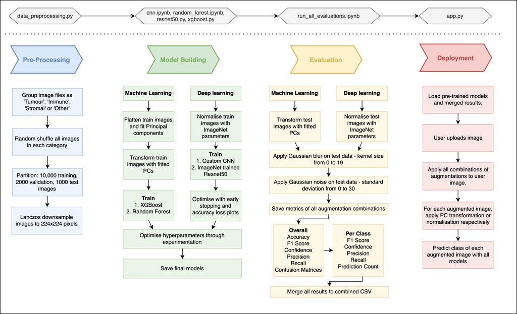

Diagram illustrating the experimental workflow and deployment pipeline. Each step is annotated with the corresponding Python script used, enabling full reproducibility of the process.

# 2 Background

The medical field is increasingly turning to Computer Vision models for classification tasks, often distinguishing cell types. With rapid increases in the field, models have come to accuracies of up to 98.5%<sup>1</sup>, slightly above that of an experienced human pathologist<sup>2</sup>. The question becomes, can these models maintain their performance in day-to-day practice? In real life, cell images do not always have perfect quality. Investigating how drops in image quality impact classification performance will give medical imagers a better view of how these models will perform on real data.

To address this issue, it is first necessary to determine the common causes and kinds of image degradation. These vary greatly depending on the situation, for example, motion blur is a typical challenge for MRIs<sup>3</sup>. This report, however, centers on histological H&E stained tissue slides, specifically of breast cancer tissue<sup>4</sup>. The major cause of quality issues in this case is ‘Whole Slide Imaging’ or WSI causing blur and noise.<sup>5</sup>

WSI is the common practice of scanning full microscope slides, rather than scanning section by section.<sup>5</sup> It has reduced the processing time of a single slide to mere minutes, but there are trade-offs in image quality. Focal points are the points where the camera centers its focus, they are selected automatically or manually. As microscope slides are three-dimensional, if a focus point is selected on a region with different depth to the typical focus depth of the slide, its neighbouring areas will be out of focus. This will lead to blur issues, and more prominent noise due to the camera’s failure to fully capture high frequency information like texture and edges.<sup>6</sup>

There are ways to mitigate image quality drops: increasing the number of focal points will reduce the prominence of the issue, but not eradicate it entirely. Further, this will also increase processing time, inconveniencing patients and adding delays on overloaded labs.<sup>5</sup> Imaging technology is advancing quickly, but with their prohibitive expense, the issue is likely to persist.

# 3 Method

**Data Collection**

Data was sourced originally from the Gene Expression Omnibus, a source of publicly available biomedical data. The images were taken with a Xenium Analyser. This gives spatial gene information as well as high resolution imaging<sup>4</sup>, so will likely have higher image quality than a typical testing set taken with WSI. The images were of whole slides, but were segmented and cropped into individual cell types and labelled accordingly<sup>7</sup>. While images of magnification levels 50 and 100 were available, only 100 level images were selected due to their higher historical performance<sup>8</sup> and computational constraints. Analysis was performed on these labelled images.

**Pre-Processing**

Images were read in as pixels, and resized to 224x224 pixels with Lanczos downsampling<sup>9</sup> to ensure that augmentation effects were standard among all images.

**Model Development**

To assess the impact of reduced image quality on classification performance, two classical machine learning models and two deep learning models were trained to compare their robustness and find if one had an advantage over the other.

For the deep learning models, a custom Convolutional Neural Network (CNN)<sup>10</sup> and a ResNet50 model pretrained on the ImageNet dataset<sup>11</sup> were selected. This gave one shallower model trained expressly for the given classification task, and one deeper model trained on 14 million diverse images, to test a spectrum of deep learning architectures. Training and testing images for these models were normalised with ImageNet normalisation parameters, required by the ResNet50<sup>12</sup> and applied to the CNN for comparability of results.

For machine learning models, an XGBoost<sup>13</sup> and a Random Forest<sup>14</sup> model were trained to compare a traditional method with a more modern one. Three methods of model input were tested: raw pixels, Histogram of Gradients (HOG) and Principal Component Analysis (PCA)<sup>15</sup>.

All models underwent extensive hyperparameter optimisation, including nested cross-validation, and early-stopping for deep learning models using the validation set.

**Evaluation**

Models were tested using the same testing set at different augmentation levels and combinations of Gaussian blur and noise to simulate WSI damage<sup>6</sup>. Initially both were tested at small increments, which were increased once a pattern emerged to manage computation, ending with blur radius levels of 0, 1, 3, 5, 7, 9 and 19 pixels and noise standard deviations of 0, 1, 3, 5, 10, 20 and 30.

To evaluate overall performance, metrics of accuracy, confusion matrices, average maximum confidence and weighted F1, precision, recall scores were taken. For a per class breakdown, metrics of precision, recall, f1, average confidence and standard deviation and prediction count were taken.

# 4 Results

**Machine vs Deep Learning**

### 4.0.1 Deep Learning

Noise causes the sharpest drop in accuracy for the CNN and ResNet50 models, with ResNet50 dropping to 30% after noise reaches a standard deviation of 1. The CNN has a slower impact, having negligible impact from noise levels up to 3, then dropping steeply. Both models are highly effective in extracting spatial features from data - relating the information of several neighbouring pixels rather than individual values. Due to these close pixel relationships in the CNNs, it makes sense that slight changes to each pixel’s colour - and subsequently all surrounding pixels - would have a significant impact on the model’s performance. Other research has correlated these findings, such as<sup>16</sup> who showed that using denoising software NoisyEnsembles improved their CNN performance.

Similarly to noise, blur caused a quick drop-off in the CNN models’ performances. While not as pronounced nor severe as with noise, there was still a marked decrease across all metrics after blur increased in kernel size beyond 9 pixels. This result is not unsurprising as even to the human eye, this level of blurring appears to be significant. This is consistent with the performance seen above with Gaussian noise applied, however to a less extreme extent as neighbouring pixels are not being altered using the same normally random distribution, rather as a function of their neighbouring colour channels. As a result the impact of blurring is less intense at low levels than noise, with only minor performance decreases.

Several other studies have similar findings, showing that models trained using sharp images struggle to generalise with images that have been blurred.<sup>17</sup> interestingly tested the effects of training CNNs using blurred images originally, then sharp images later and found that these models consistently performed better than those that were trained using only sharp images (as we have done in our investigation).

### 4.0.2 Machine Learning

On the other hand, although starting at lower accuracies the machine learning models are more robust to drops in quality. Both models have limited drops with a blur kernel size of up to 5 and hardly any impact from noise levels of up to 30.

The machine learning models are slightly less robust to blur. As blur increases, the linear transformation can detect less information. However, even at extreme levels where it is uninterpretable to the human eye, the model can still extract colour, spatial and intensity information. Again, due to its global nature it is able to capture larger scale features, so it can continue extracting relevant patterns even with limited local information.

Therefore in the case of image quality concerns, the PCA transformed XGBoost model will give the best result, otherwise ResNet50 will outperform all other models when image quality is high.

# 5 Application Development

The application is designed to complement the real-world workflows of medical imaging professionals and diagnosticians, where visual assessment is central. By pairing augmented images with model performance metrics, it bridges the gap between human judgement and machine classification, supporting interdisciplinary decision-making. The backend integrates two key pipelines: a pre-computed (but dynamically updatable) metrics pipeline, and pre-trained models that allow new predictions from user-uploaded images.

Page 1 displays example cell images from each class under user-selected blur and noise levels, alongside graphical performance summaries to allow quick model comparison under the augmentations applied.

Page 2 provides per-model class-level performance, including confidence and confusion matrices, supporting evaluation of model reliability and cell-type-specific performance as required.

Page 3 allows users to upload an image and view predictions across all augmentation combinations, helping assess model behaviour under novel, real-world image conditions.